# Power Analysis for Targeted Proteomics with Missing Data (PRM)

peppwR

2026-02-02

## Introduction

### What Makes Targeted Proteomics Different?

Mass spectrometry-based proteomics operates in two fundamentally different modes:

**Discovery proteomics (DDA)** casts a wide net:

- Measures thousands of proteins/peptides
- Identifies whatever is abundant enough to detect
- Great for hypothesis generation
- High multiple testing burden

**Targeted proteomics (PRM/SRM)** takes aim at specific targets:

- Measures a pre-defined panel of peptides
- Higher sensitivity and reproducibility
- Better for hypothesis testing
- Lower multiple testing burden

This document analyzes a PRM dataset, demonstrating how peppwR handles the unique challenges of targeted proteomics, including missing data and FDR considerations.

### The Missing Data Challenge

Even with targeted methods, missing values are ubiquitous in mass spectrometry. But not all missing data is created equal:

**MCAR (Missing Completely At Random)**

- Values missing due to random technical failures
- No relationship to abundance
- Reduces sample size but doesn’t bias results

**MNAR (Missing Not At Random)**

- Low-abundance peptides systematically missing
- Below detection limit = no measurement
- Can bias abundance estimates upward
- Common in mass spectrometry

peppwR tracks both the rate of missingness AND evidence for MNAR patterns, enabling more realistic power estimates.

### Goals of This Analysis

1. Characterize missingness patterns in the data
2. Identify peptides with MNAR evidence
3. Compare statistical tests at small sample sizes
4. Determine realistic sample size requirements
5. Understand FDR impact on power

## About the Data

This analysis uses fungal phosphoproteomics data from a targeted PRM experiment:

| Property | Value |
| --- | --- |
| Organism | *Magnaporthe oryzae* (rice blast fungus) |
| Method | PRM (Parallel Reaction Monitoring) |
| Comparison | Early (t=0) vs late (t=6) timepoints |
| Biological replicates | 3 per condition |
| Technical replicates | 2 per biological replicate |
| Peptides | 285 phosphopeptides |
| Missing data | ~17% |

## Data Preparation

```r
library(peppwR)
library(dplyr)
library(ggplot2)
library(tibble)
```

```r
# Load the PRM experiment data
prm <- read.csv("../../sample_data/prm_data.csv")

# Examine the structure
glimpse(prm)
```

```
## Rows: 20,520
## Columns: 7
## $ molecule_list_name        <chr> "gi|145601729|ref|XP_363034.2|", "gi|1456017…
## $ peptide_modified_sequence <chr> "KLS[+80]ASGS[+80]PGSVNLGR", "KLS[+80]ASGS[+…
## $ genotype                  <chr> "Guy11", "Guy11", "Guy11", "Guy11", "Guy11",…
## $ timepoint                 <dbl> 0.0, 0.0, 0.0, 0.0, 0.0, 0.0, 1.0, 1.0, 1.0,…
## $ bio_rep                   <int> 1, 1, 2, 2, 3, 3, 1, 1, 2, 2, 3, 3, 1, 1, 2,…
## $ tech_rep                  <int> 1, 2, 1, 2, 1, 2, 1, 2, 1, 2, 1, 2, 1, 2, 1,…
## $ total_area                <dbl> 1.031275e-03, 1.130267e-03, 5.243216e-04, 2.…
```

```r
# Check for missing values in raw data
cat("Total observations:", nrow(prm), "\n")
```

```
## Total observations: 20520
```

```r
cat("Missing values:", sum(is.na(prm$total_area)), "\n")
```

```
## Missing values: 3547
```

```r
cat("Missing rate:", round(mean(is.na(prm$total_area)) * 100, 1), "%\n")
```

```
## Missing rate: 17.3 %
```

### Why Average Technical Replicates?

Technical replicates measure the same biological sample multiple times. They capture *measurement* variability, not *biological* variability.

For power analysis, biological replicates are the true unit of replication - they represent independent observations of the biological phenomenon we’re studying. We average technical replicates to get one value per biological replicate.

```r
# Filter to early (0) vs late (6) timepoints
# Average technical replicates within each biological replicate
pilot <- prm |>
  filter(timepoint %in% c(0, 6)) |>
  group_by(peptide_modified_sequence, genotype, timepoint, bio_rep) |>
  summarise(abundance = mean(total_area, na.rm = TRUE), .groups = "drop") |>
  transmute(
    peptide_id = peptide_modified_sequence,
    condition = paste0("t", timepoint),
    abundance = abundance
  )

# Summary statistics
cat("Unique peptides:", n_distinct(pilot$peptide_id), "\n")
```

```
## Unique peptides: 285
```

```r
cat("Observations per condition:\n")
```

```
## Observations per condition:
```

```r
pilot |> count(condition)
```

```
## # A tibble: 2 × 2
##   condition     n
##   <chr>     <int>
## 1 t0         1710
## 2 t6         1710
```

```r
# Check missingness after averaging technical replicates
# (NaN results when both tech reps are NA)
pilot <- pilot |>
  mutate(abundance = ifelse(is.nan(abundance), NA, abundance))

cat("Missing after averaging tech reps:", sum(is.na(pilot$abundance)), "\n")
```

```
## Missing after averaging tech reps: 429
```

```r
cat("Missing rate:", round(mean(is.na(pilot$abundance)) * 100, 1), "%\n")
```

```
## Missing rate: 12.5 %
```

## Missingness Analysis

### Examining the Extent of Missingness

Before diving into power analysis, we need to understand our missing data. peppwR automatically computes missingness statistics during distribution fitting.

```r
# Fit distributions - missingness is tracked automatically
fits <- fit_distributions(pilot, "peptide_id", "condition", "abundance")

# Summary includes missingness information
print(fits)
```

```
## peppwr_fits object
## ------------------
## 570 peptides fitted
##
## Best fit distribution counts:
##   Gamma: 93
##   Inverse Gaussian: 36
##   InvGamma: 2
##   Lognormal: 5
##   Normal: 49
##   Pareto: 268
##   Skew Normal: 117
##
## Missingness: 429/3420 values NA (12.5%)
## Peptides with missing data: 180
##   MNAR pattern: 0 of 180 peptides with missing data (score > 2)
```

### Visualizing Missingness Patterns

The `plot_missingness()` function provides three complementary views:

1. **NA Rate Distribution**: What fraction of observations are missing for each peptide?
2. **MNAR Score Distribution**: Is there evidence that missingness correlates with abundance?
3. **Abundance vs NA Rate**: Do low-abundance peptides have more missing values?

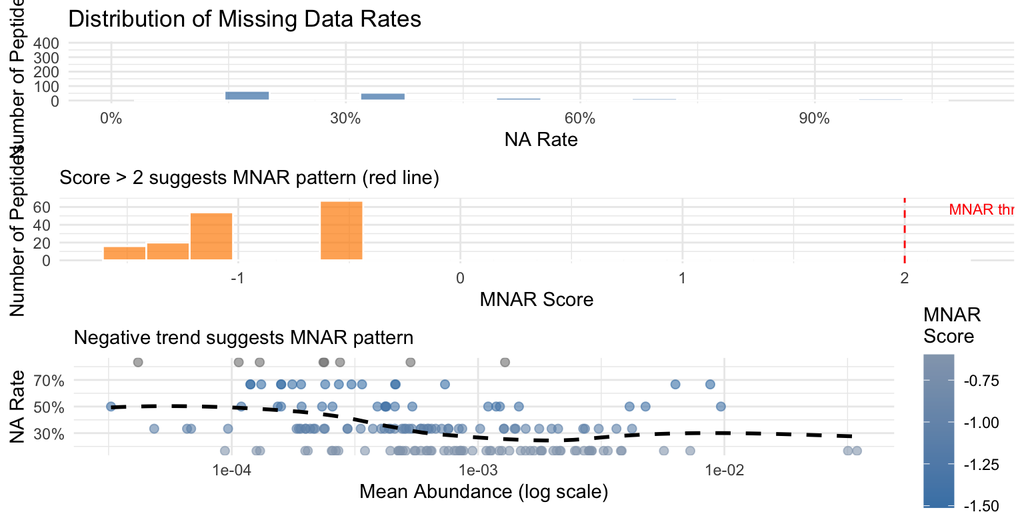

```r
plot_missingness(fits)
```

### Interpreting MNAR Scores

The MNAR score is a z-statistic testing whether missing observations have systematically different (lower) abundance than observed values. Higher scores indicate stronger evidence for informative missingness.

| MNAR Score | Interpretation |
| --- | --- |
| < 1 | Little evidence for MNAR |
| 1-2 | Weak evidence |
| 2-3 | Moderate evidence |
| > 3 | Strong evidence for MNAR |

```r
# Identify peptides with strong MNAR evidence
mnar_peptides <- get_mnar_peptides(fits, threshold = 2)

cat("Peptides with MNAR evidence (z > 2):", nrow(mnar_peptides), "\n")
```

```
## Peptides with MNAR evidence (z > 2): 0
```

```r
if (nrow(mnar_peptides) > 0) {
  cat("\nTop MNAR peptides:\n")
  print(head(mnar_peptides, 10))
}
```

### What to Do with MNAR Peptides

Peptides with high MNAR scores require careful handling:

- Their abundance estimates may be biased upward (low values are missing)
- Power calculations may be optimistic
- Consider robust statistical methods
- Report separately in publications

## Distribution Fitting Results

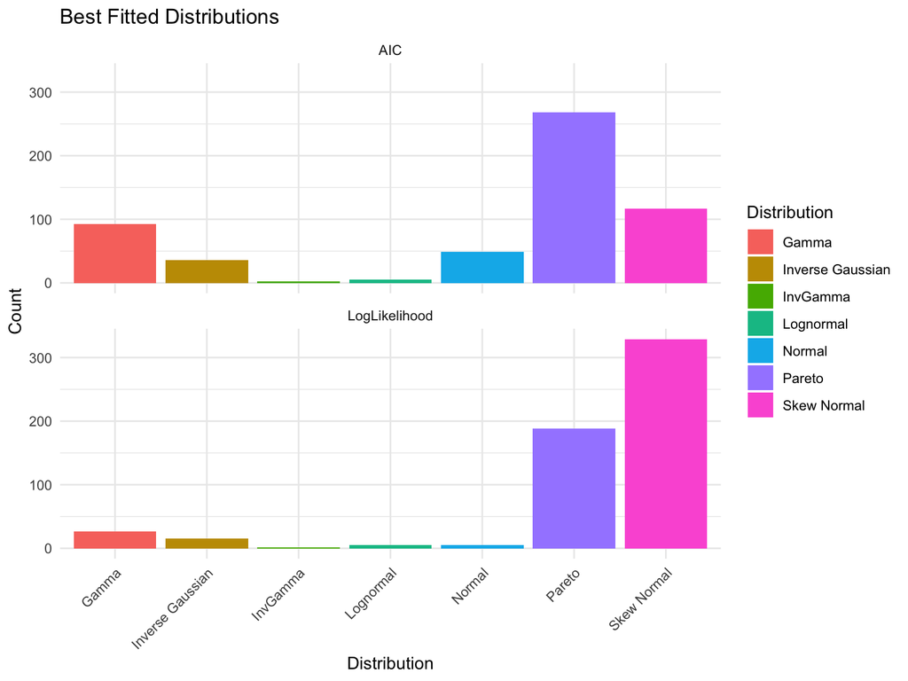

Best-fit distribution counts for PRM data.

```r
plot(fits)
```

### Interpreting Distribution Fitting: A Cautionary Note

**Important:** Like the DDA dataset, we see that certain distributions may dominate the “best fit” counts. This is an **artifact of small sample size** (only 6 observations per peptide when averaged across tech reps), not a statement about true underlying distributions.

With more biological replicates, we would expect gamma and lognormal distributions to fit better - these are the typical distributions for mass spectrometry abundance data.

### Parameter Distribution

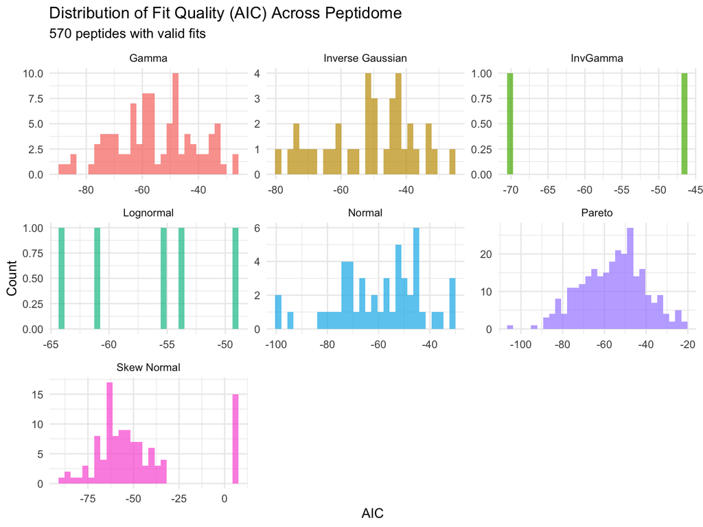

Distribution of AIC values across peptides for each fitted distribution.

```r
p <- plot_param_distribution(fits)
print(p)
```

```r
# Count peptides per best-fit distribution
cat("\nPeptides per best-fit distribution:\n")
```

```
##
## Peptides per best-fit distribution:
```

```r
tibble(distribution = fits$best) |>
  count(distribution) |>
  arrange(desc(n))
```

```
## # A tibble: 7 × 2
##   distribution         n
##   <chr>            <int>
## 1 Pareto             268
## 2 Skew Normal        117
## 3 Gamma               93
## 4 Normal              49
## 5 Inverse Gaussian    36
## 6 Lognormal            5
## 7 InvGamma             2
```

## Power Analysis

### Choosing the Right Statistical Test

**Critical first step:** With small samples (N=3), test choice dramatically affects power. Before committing to detailed analyses, we compare available tests.

| Test | Type | Characteristics |
| --- | --- | --- |
| Wilcoxon rank-sum | Non-parametric | Conservative, robust to outliers, needs larger N |
| Bootstrap-t | Resampling | Handles non-normality through resampling |
| Bayes factor | Bayesian | Evidence-based, often more powerful at small N |

```r
# Run all three tests (use n_sim = 100 for faster rendering)
power_wilcox <- power_analysis(fits, effect_size = 2, n_per_group = 3,
                                find = "power", test = "wilcoxon", n_sim = 100)

power_boot <- power_analysis(fits, effect_size = 2, n_per_group = 3,
                              find = "power", test = "bootstrap_t", n_sim = 100)

power_bayes <- power_analysis(fits, effect_size = 2, n_per_group = 3,
                               find = "power", test = "bayes_t", n_sim = 100)

# Create comparison table
comparison <- tibble(
  Test = c("Wilcoxon rank-sum", "Bootstrap-t", "Bayes factor"),
  `Median Power` = c(
    median(power_wilcox$simulations$peptide_power, na.rm = TRUE),
    median(power_boot$simulations$peptide_power, na.rm = TRUE),
    median(power_bayes$simulations$peptide_power, na.rm = TRUE)
  ),
  `% > 50% Power` = c(
    mean(power_wilcox$simulations$peptide_power > 0.5, na.rm = TRUE) * 100,
    mean(power_boot$simulations$peptide_power > 0.5, na.rm = TRUE) * 100,
    mean(power_bayes$simulations$peptide_power > 0.5, na.rm = TRUE) * 100
  ),
  `% > 80% Power` = c(
    mean(power_wilcox$simulations$peptide_power > 0.8, na.rm = TRUE) * 100,
    mean(power_boot$simulations$peptide_power > 0.8, na.rm = TRUE) * 100,
    mean(power_bayes$simulations$peptide_power > 0.8, na.rm = TRUE) * 100
  )
)

knitr::kable(comparison, digits = 2,
             caption = "Power comparison across statistical tests (N=3, 2-fold effect)")
```

Power comparison across statistical tests (N=3, 2-fold effect)

| Test | Median Power | % > 50% Power | % > 80% Power |
| --- | --- | --- | --- |
| Wilcoxon rank-sum | 0.00 | 0.00 | 0.00 |
| Bootstrap-t | 0.21 | 11.11 | 4.66 |
| Bayes factor | 0.58 | 63.44 | 16.49 |

### Understanding the Test Comparison Results

The table above shows how different tests perform at small sample sizes:

- **Wilcoxon rank-sum** is conservative - non-parametric tests trade statistical assumptions for larger sample size requirements.
- **Bootstrap-t** uses resampling to handle non-normality, potentially offering intermediate power.
- **Bayes factor** tests quantify evidence for an effect, often performing better at small N.

**For remaining analyses:** We use the Bayes factor test since it provides usable power estimates at N=3.

### The Three Questions

Power analysis can answer three related questions:

1. **Power:** Given N and effect size, what power do we have?
2. **Sample size:** Given target power and effect size, what N do we need?
3. **Minimum detectable effect:** Given N and target power, what effect can we detect?

### Question 1: What Power Do We Have?

With 3 biological replicates and a 2-fold effect, what power do we achieve?

```r
# Using Bayes factor test based on comparison results
power_current <- power_analysis(fits, effect_size = 2, n_per_group = 3,
                                 find = "power", test = "bayes_t", n_sim = 100)
print(power_current)
```

```
## peppwr_power analysis
## ---------------------
## Mode: per_peptide
##
## Power: 60%
## Sample size: 3 per group
## Effect size: 2.00-fold
##
## Significance level: 0.05
## Statistical test: bayes_t
```

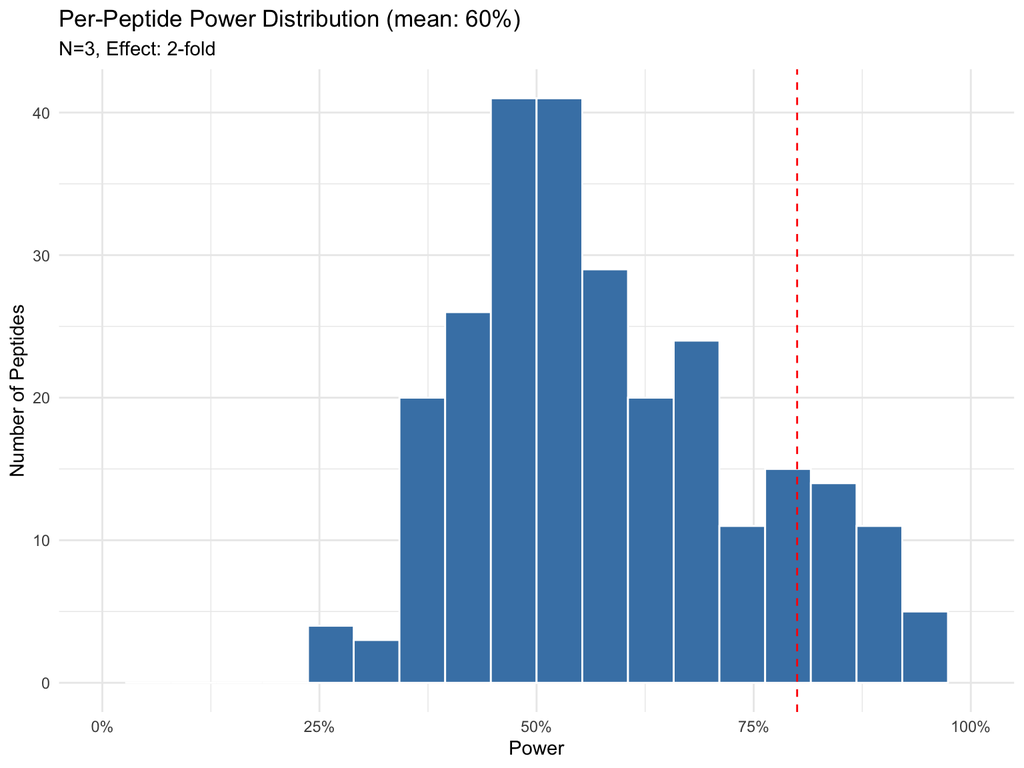

Distribution of power across peptides with N=3 and 2-fold effect (Bayes factor test).

```r
plot(power_current)
```

### Question 2: What Sample Size Do We Need?

What N would achieve 80% power to detect a 2-fold change?

```r
sample_size <- power_analysis(fits, effect_size = 2, target_power = 0.8,
                              find = "sample_size", test = "bayes_t", n_sim = 100)
print(sample_size)
```

```
## peppwr_power analysis
## ---------------------
## Mode: per_peptide
##
## Recommended sample size: N=10 per group
## Target power: 80%
## Effect size: 2.00-fold
##
## Significance level: 0.05
## Statistical test: bayes_t
```

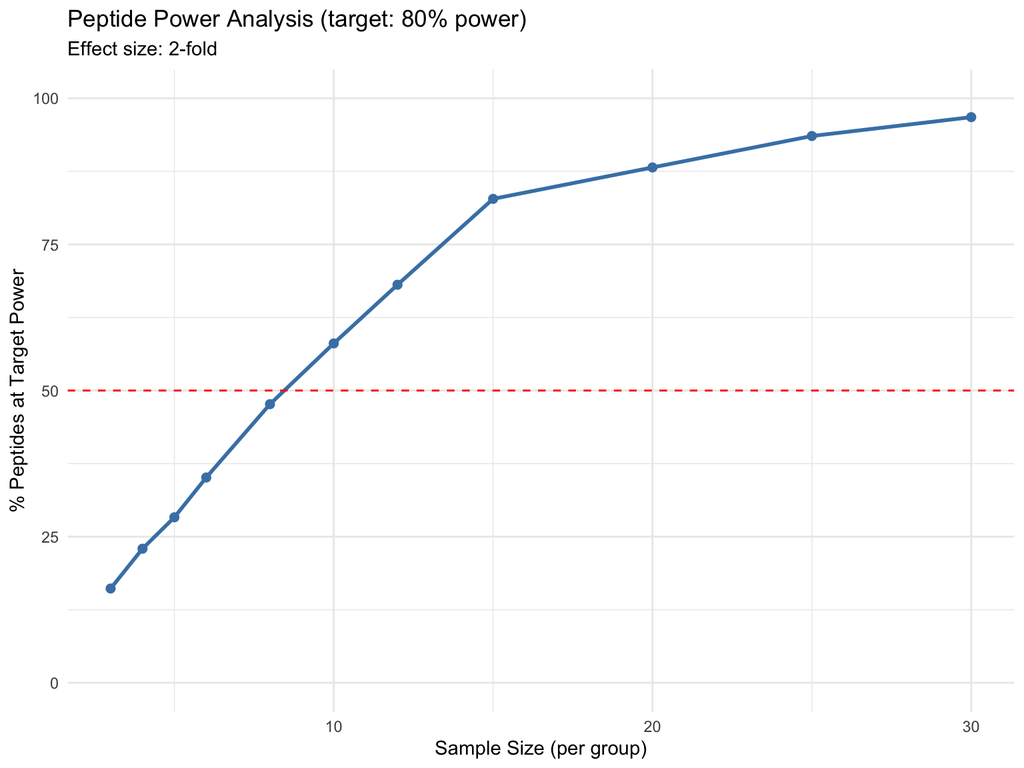

Percentage of peptides achieving 80% power at each sample size.

```r
plot(sample_size)
```

### Question 3: What’s the Minimum Detectable Effect?

At N=3, what’s the smallest effect we can reliably detect?

```r
min_effect <- power_analysis(fits, n_per_group = 3, target_power = 0.8,
                             find = "effect_size", test = "bayes_t", n_sim = 100)
print(min_effect)
```

```
## peppwr_power analysis
## ---------------------
## Mode: per_peptide
##
## Minimum detectable effect: 5.00-fold
## Sample size: 3 per group
## Target power: 80%
##
## Significance level: 0.05
## Statistical test: bayes_t
```

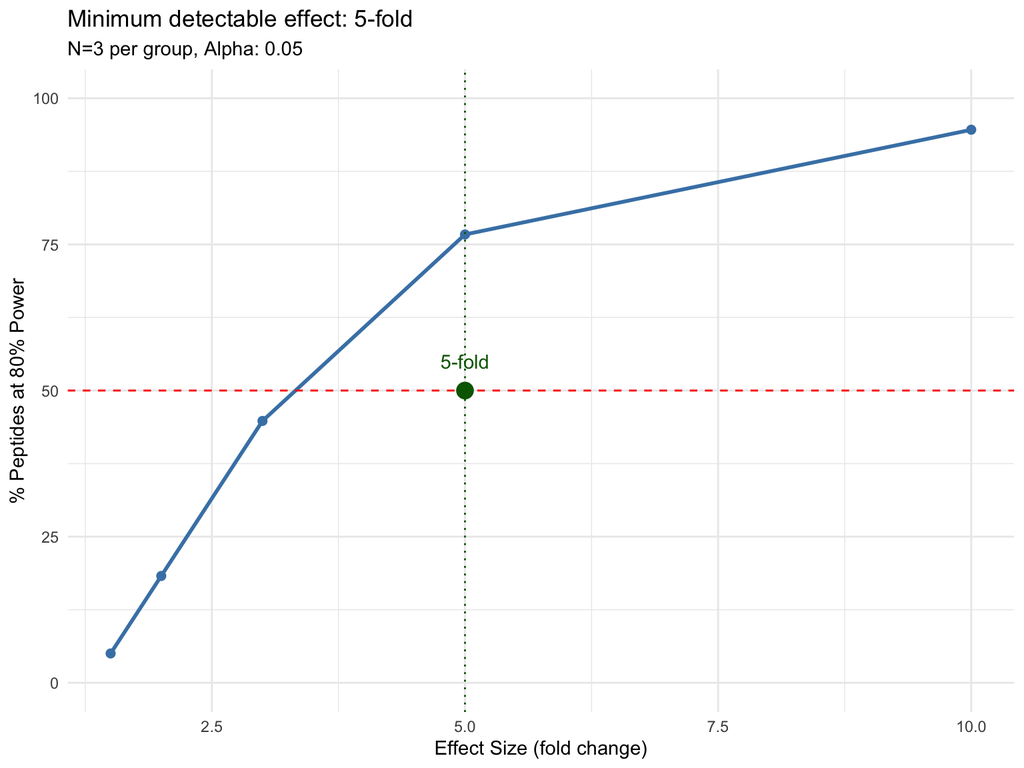

```r
plot(min_effect)
```

This tells us what effect sizes are realistically detectable with current sample sizes.

### Impact of Missingness on Power

How does accounting for missingness affect power estimates?

```r
# Power without accounting for missingness (optimistic)
power_no_miss <- power_analysis(fits, effect_size = 2, n_per_group = 3,
                                 find = "power", test = "bayes_t",
                                 include_missingness = FALSE, n_sim = 100)

# Power accounting for missingness (realistic)
power_with_miss <- power_analysis(fits, effect_size = 2, n_per_group = 3,
                                   find = "power", test = "bayes_t",
                                   include_missingness = TRUE, n_sim = 100)

cat("Median power WITHOUT missingness:",
    round(median(power_no_miss$simulations$peptide_power, na.rm = TRUE), 3), "\n")
```

```
## Median power WITHOUT missingness: 0.57
```

```r
cat("Median power WITH missingness:   ",
    round(median(power_with_miss$simulations$peptide_power, na.rm = TRUE), 3), "\n")
```

```
## Median power WITH missingness:    0.55
```

Accounting for missingness typically reduces power estimates - this is the realistic cost of missing data on your experiment’s ability to detect effects.

## FDR-Aware Power Analysis

### Why FDR Matters

With 285 peptides tested, multiple testing is a concern. If we use alpha = 0.05 for each test, we expect ~14 false positives by chance alone (285 x 0.05 = 14.25).

FDR (False Discovery Rate) control methods like Benjamini-Hochberg adjust p-values to control the expected proportion of false discoveries. This is more stringent than nominal testing and reduces power.

### Understanding `prop_null`

The `prop_null` parameter specifies the assumed proportion of true null hypotheses - peptides with no real effect. This affects FDR correction stringency:

| `prop_null` | Meaning | Impact |
| --- | --- | --- |
| 0.9 | 90% of peptides have no effect | More stringent correction |
| 0.5 | 50% have real effects | Less stringent correction |

In targeted proteomics, you typically select peptides expected to change, so `prop_null` might be lower than in discovery experiments.

### Standard vs FDR-Corrected Power

```r
# Standard power (nominal alpha = 0.05)
power_nominal <- power_analysis(fits, effect_size = 2, n_per_group = 3,
                                find = "power", test = "bayes_t",
                                apply_fdr = FALSE, n_sim = 100)

# FDR-aware power (BH correction)
# prop_null = 0.8 means we assume 80% of peptides have no true effect
power_fdr <- power_analysis(fits, effect_size = 2, n_per_group = 3,
                            find = "power", test = "bayes_t",
                            apply_fdr = TRUE, prop_null = 0.8,
                            fdr_threshold = 0.05, n_sim = 100)
```

```r
# Extract power values safely
nominal_power <- power_nominal$simulations$peptide_power
fdr_power <- power_fdr$simulations$peptide_power

cat("Nominal power (no FDR correction):\n")
```

```
## Nominal power (no FDR correction):
```

```r
if (is.numeric(nominal_power) && length(nominal_power) > 0) {
  cat("  Median power:", round(median(nominal_power, na.rm = TRUE), 3), "\n")
  cat("  % peptides > 80% power:", round(mean(nominal_power > 0.8, na.rm = TRUE) * 100, 1), "%\n")
} else {
  print(power_nominal)
}
```

```
##   Median power: 0.57
##   % peptides > 80% power: 16.8 %
```

```r
cat("\nFDR-aware power (BH correction, 80% true nulls):\n")
```

```
##
## FDR-aware power (BH correction, 80% true nulls):
```

```r
if (is.numeric(fdr_power) && length(fdr_power) > 0) {
  cat("  Median power:", round(median(fdr_power, na.rm = TRUE), 3), "\n")
  cat("  % peptides > 80% power:", round(mean(fdr_power > 0.8, na.rm = TRUE) * 100, 1), "%\n")
} else {
  print(power_fdr)
}
```

```
## peppwr_power analysis
## ---------------------
## Mode: per_peptide
##
## Power: 6%
## Sample size: 3 per group
## Effect size: 2.00-fold
##
## Significance level: 0.05
## Statistical test: bayes_t
##
## FDR-adjusted analysis (Benjamini-Hochberg)
## Proportion true nulls: 80%
## FDR threshold: 5%
```

### Understanding the FDR Impact

FDR correction reduces power because:

1. **More evidence required:** Adjusted p-values are larger, requiring stronger effects to reach significance
2. **Depends on number of tests:** More peptides = more stringent correction
3. **Depends on true effect proportion:** If most peptides have true effects (`prop_null` is low), FDR correction is less severe

## Summary and Recommendations

### Targeted vs Discovery Considerations

This PRM dataset (285 peptides) has advantages over discovery proteomics:

- **Lower multiple testing burden:** Fewer tests = less severe FDR correction
- **Focused power:** Resources concentrated on peptides of interest
- **Better reproducibility:** Targeted methods have lower technical variability

However:

- **No discovery:** Can’t detect unexpected changes
- **Panel bias:** Limited to pre-selected targets

### Caveats

- This analysis combines both genotypes; genotype-specific analyses may differ
- Technical replicate averaging reduces noise but masks technical variability
- MNAR models are approximations; true missing data mechanisms may be more complex
- The `prop_null` parameter requires assumptions about true effect rates
- Distribution fitting is limited by small sample size